# Reccomendation Place in Yogyakarta

Fikri K Rizal

2022-07-26

# 1 Explanation

Before travelling, usually we will make a holiday plan about our destination. This project give a little describe about some tourist destination in Yogyakarta.

# 2 Input Data

```r
rating <- read.csv("Data Input/tourism_rating.csv")
place <- read.csv("Data Input/tourism_with_id.csv")
user <- read.csv("Data Input/user.csv")
```

So!! This is our destination data, let’s go to next step

## 2.1 Data Inspection

There are many ways to inspect our data, we can use ‘head()’, ‘tail()’, ‘dim()’, or ‘names()’. We have 3 datas, so we will check each data.

### 2.1.1 Rating Data

```r
head(rating)
```

|  | User_Id | Place_Id | Place_Ratings |
| --- | --- | --- | --- |
| 1 | 1 | 179 | 3 |
| 2 | 1 | 344 | 2 |
| 3 | 1 | 5 | 5 |
| 4 | 1 | 373 | 3 |
| 5 | 1 | 101 | 4 |
| 6 | 1 | 312 | 2 |

```r
dim(rating)
```

```
#> [1] 10000     3
```

```r
names(rating)
```

```
#> [1] "User_Id"       "Place_Id"      "Place_Ratings"
```

### 2.1.2 Place Data

```r
head(place)
```

|  | Place_Id | Place_Name | Description | Category | City | Price | Rating | Time_Minutes | Coordinate | Lat | Long | X | X.1 |
| --- | --- | --- | --- | --- | --- | --- | --- | --- | --- | --- | --- | --- | --- |
| 1 | 1 | Monumen Nasional | Monumen Nasional atau yang populer disingkat dengan Monas atau Tugu Monas adalah monumen peringatan setinggi 132 meter (433 kaki) yang didirikan untuk mengenang perlawanan dan perjuangan rakyat Indone… | Budaya | Jakarta | 20000 | 4.6 | 15 | {'lat': -6.1753924, 'lng': 106.8271528} | -6.175392 | 106.8272 | NA | 1 |
| 2 | 2 | Kota Tua | Kota tua di Jakarta, yang juga bernama Kota Tua, berpusat di Alun-Alun Fatahillah, yaitu alun-alun yang ramai dengan pertunjukan rutin tarian tradisional. Museum Sejarah Jakarta adalah bangunan era Be… | Budaya | Jakarta | 0 | 4.6 | 90 | {'lat': -6.137644799999999, 'lng': 106.8171245} | -6.137645 | 106.8171 | NA | 2 |
| 3 | 3 | Dunia Fantasi | Dunia Fantasi atau disebut juga Dufan adalah tempat hiburan yang terletak di kawasan Taman Impian Jaya Ancol, Jakarta Utara, Indonesia. Dufan diresmikan dan dibuka pada tanggal 29 Agustus 1985. | Taman Hiburan | Jakarta | 270000 | 4.6 | 360 | {'lat': -6.125312399999999, 'lng': 106.8335377} | -6.125312 | 106.8335 | NA | 3 |
| 4 | 4 | Taman Mini Indonesia Indah (TMII) | Taman Mini Indonesia Indah merupakan suatu kawasan taman wisata bertema budaya Indonesia di Jakarta Timur. Area seluas kurang lebih 150 hektare atau 1,5 kilometer persegi ini terletak pada koordinat 6… | Taman Hiburan | Jakarta | 10000 | 4.5 | NA | {'lat': -6.302445899999999, 'lng': 106.8951559} | -6.302446 | 106.8952 | NA | 4 |
| 5 | 5 | Atlantis Water Adventure | Atlantis Water Adventure atau dikenal dengan Atlantis Ancol akan menyuguhkan petualangan wisata air tak terlupakan. Tempat Wisata bertemakan permainan air dengan luas 5 hektar ini memberi sensasi petu… | Taman Hiburan | Jakarta | 94000 | 4.5 | 60 | {'lat': -6.12419, 'lng': 106.839134} | -6.124190 | 106.8391 | NA | 5 |
| 6 | 6 | Taman Impian Jaya Ancol | Taman Impian Jaya Ancol merupakan sebuah objek wisata di Jakarta Utara.\\n\\n | Taman Hiburan | Jakarta | 25000 | 4.5 | 10 | {'lat': -6.117333200000001, 'lng': 106.8579951} | -6.117333 | 106.8580 | NA | 6 |

```r
dim(place)
```

```
#> [1] 437  13
```

```r
names(place)
```

```
#>  [1] "Place_Id"     "Place_Name"   "Description"  "Category"     "City"
#>  [6] "Price"        "Rating"       "Time_Minutes" "Coordinate"   "Lat"
#> [11] "Long"         "X"            "X.1"
```

### 2.1.3 User Data

```r
head(user)
```

|  | User_Id | Location | Age |
| --- | --- | --- | --- |
| 1 | 1 | Semarang, Jawa Tengah | 20 |
| 2 | 2 | Bekasi, Jawa Barat | 21 |
| 3 | 3 | Cirebon, Jawa Barat | 23 |
| 4 | 4 | Bekasi, Jawa Barat | 21 |
| 5 | 5 | Lampung, Sumatera Selatan | 20 |
| 6 | 6 | Jakarta Utara, DKI Jakarta | 18 |

```r
dim(user)
```

```
#> [1] 300   3
```

```r
names(user)
```

```
#> [1] "User_Id"  "Location" "Age"
```

From rating, place and user data, there are correlation from each other. Rating & place data, have correlation from “Place_Id”, and rating & user data have correlation from User_Id.

# 3 Data Cleansing

## 3.1 Check Data Types

```r
str(rating)
```

```
#> 'data.frame':    10000 obs. of  3 variables:
#>  $ User_Id      : int  1 1 1 1 1 1 1 1 1 1 ...
#>  $ Place_Id     : int  179 344 5 373 101 312 258 20 154 393 ...
#>  $ Place_Ratings: int  3 2 5 3 4 2 5 4 2 5 ...
```

```r
str(place)
```

```
#> 'data.frame':    437 obs. of  13 variables:
#>  $ Place_Id    : int  1 2 3 4 5 6 7 8 9 10 ...
#>  $ Place_Name  : chr  "Monumen Nasional" "Kota Tua" "Dunia Fantasi" "Taman Mini Indonesia Indah (TMII)" ...
#>  $ Description : chr  "Monumen Nasional atau yang populer disingkat dengan Monas atau Tugu Monas adalah monumen peringatan setinggi 13"| __truncated__ "Kota tua di Jakarta, yang juga bernama Kota Tua, berpusat di Alun-Alun Fatahillah, yaitu alun-alun yang ramai d"| __truncated__ "Dunia Fantasi at…
#>  $ Category    : chr  "Budaya" "Budaya" "Taman Hiburan" "Taman Hiburan" ...
#>  $ City        : chr  "Jakarta" "Jakarta" "Jakarta" "Jakarta" ...
#>  $ Price       : int  20000 0 270000 10000 94000 25000 4000 180000 175000 150000 ...
#>  $ Rating      : num  4.6 4.6 4.6 4.5 4.5 4.5 4.5 4 4.4 4.5 ...
#>  $ Time_Minutes: int  15 90 360 NA 60 10 NA NA NA NA ...
#>  $ Coordinate  : chr  "{'lat': -6.1753924, 'lng': 106.8271528}" "{'lat': -6.137644799999999, 'lng': 106.8171245}" "{'lat': -6.125312399999999, 'lng': 106.8335377}" "{'lat': -6.302445899999999, 'lng': 106.8951559}" ...
#>  $ Lat         : num  -6.18 -6.14 -6.13 -6.3 -6.12 ...
#>  $ Long        : num  107 107 107 107 107 ...
#>  $ X           : logi  NA NA NA NA NA NA ...
#>  $ X.1         : int  1 2 3 4 5 6 7 8 9 10 ...
```

```r
str(user)
```

```
#> 'data.frame':    300 obs. of  3 variables:
#>  $ User_Id : int  1 2 3 4 5 6 7 8 9 10 ...
#>  $ Location: chr  "Semarang, Jawa Tengah" "Bekasi, Jawa Barat" "Cirebon, Jawa Barat" "Bekasi, Jawa Barat" ...
#>  $ Age     : int  20 21 23 21 20 18 39 40 38 39 ...
```

## 3.2 Delete Unuser Column

```r
place <- place[,!names(place)%in% c("X","X.1","Time_Minutes"), drop=F]
head(place)
```

|  | Place_Id | Place_Name | Description | Category | City | Price | Rating | Coordinate | Lat | Long |
| --- | --- | --- | --- | --- | --- | --- | --- | --- | --- | --- |
| 1 | 1 | Monumen Nasional | Monumen Nasional atau yang populer disingkat dengan Monas atau Tugu Monas adalah monumen peringatan setinggi 132 meter (433 kaki) yang didirikan untuk mengenang perlawanan dan perjuangan rakyat Indone… | Budaya | Jakarta | 20000 | 4.6 | {'lat': -6.1753924, 'lng': 106.8271528} | -6.175392 | 106.8272 |
| 2 | 2 | Kota Tua | Kota tua di Jakarta, yang juga bernama Kota Tua, berpusat di Alun-Alun Fatahillah, yaitu alun-alun yang ramai dengan pertunjukan rutin tarian tradisional. Museum Sejarah Jakarta adalah bangunan era Be… | Budaya | Jakarta | 0 | 4.6 | {'lat': -6.137644799999999, 'lng': 106.8171245} | -6.137645 | 106.8171 |
| 3 | 3 | Dunia Fantasi | Dunia Fantasi atau disebut juga Dufan adalah tempat hiburan yang terletak di kawasan Taman Impian Jaya Ancol, Jakarta Utara, Indonesia. Dufan diresmikan dan dibuka pada tanggal 29 Agustus 1985. | Taman Hiburan | Jakarta | 270000 | 4.6 | {'lat': -6.125312399999999, 'lng': 106.8335377} | -6.125312 | 106.8335 |
| 4 | 4 | Taman Mini Indonesia Indah (TMII) | Taman Mini Indonesia Indah merupakan suatu kawasan taman wisata bertema budaya Indonesia di Jakarta Timur. Area seluas kurang lebih 150 hektare atau 1,5 kilometer persegi ini terletak pada koordinat 6… | Taman Hiburan | Jakarta | 10000 | 4.5 | {'lat': -6.302445899999999, 'lng': 106.8951559} | -6.302446 | 106.8952 |
| 5 | 5 | Atlantis Water Adventure | Atlantis Water Adventure atau dikenal dengan Atlantis Ancol akan menyuguhkan petualangan wisata air tak terlupakan. Tempat Wisata bertemakan permainan air dengan luas 5 hektar ini memberi sensasi petu… | Taman Hiburan | Jakarta | 94000 | 4.5 | {'lat': -6.12419, 'lng': 106.839134} | -6.124190 | 106.8391 |
| 6 | 6 | Taman Impian Jaya Ancol | Taman Impian Jaya Ancol merupakan sebuah objek wisata di Jakarta Utara.\\n\\n | Taman Hiburan | Jakarta | 25000 | 4.5 | {'lat': -6.117333200000001, 'lng': 106.8579951} | -6.117333 | 106.8580 |

## 3.3 Select Location only from Yogyakarta

```r
place_yogya <- place[place$City=="Yogyakarta",]
head(place_yogya)
```

|  | Place_Id | Place_Name | Description | Category | City | Price | Rating | Coordinate | Lat | Long |
| --- | --- | --- | --- | --- | --- | --- | --- | --- | --- | --- |
| 85 | 85 | Taman Pintar Yogyakarta | Taman Pintar Yogyakarta (bahasa Jawa: Hanacaraka,ꦠꦩꦤ꧀ꦥꦶꦤ꧀ꦠꦂꦔꦪꦺꦴꦒꦾꦏꦂꦠ, Taman Pintar Ngayogyakarta) adalah wahana wisata yang terdapat di pusat Kota Yogyakarta, tepatnya di Jalan Panembahan Senopati N… | Taman Hiburan | Yogyakarta | 6000 | 4.5 | {'lat': -7.800671500000001, 'lng': 110.3676551} | -7.800671 | 110.3677 |
| 86 | 86 | Keraton Yogyakarta | Keraton Ngayogyakarta Hadiningrat atau Keraton Yogyakarta (bahasa Jawa: ꦏꦫꦠꦺꦴꦤ꧀ꦔꦪꦺꦴꦒꦾꦏꦂꦠꦲꦢꦶꦤꦶꦔꦿꦠ꧀, translit. Karaton Ngayogyakarta Hadiningrat) merupakan istana resmi Kesultanan Ngayogyakarta Hadini… | Budaya | Yogyakarta | 15000 | 4.6 | {'lat': -7.8052845, 'lng': 110.3642031} | -7.805284 | 110.3642 |
| 87 | 87 | Sindu Kusuma Edupark (SKE) | Sindu Kusuma Edupark (SKE) merupakan sebuah destinasi rekreasi yang terletak di Jogjakarta. Di tujuh hektar kawasan taman yang selesai dibangun tahun 2014 ini, terdapat bermacam-macam wahana, baik wah… | Taman Hiburan | Yogyakarta | 20000 | 4.2 | {'lat': -7.767297300000001, 'lng': 110.3542486} | -7.767297 | 110.3542 |
| 88 | 88 | Museum Benteng Vredeburg Yogyakarta | Museum Benteng Vredeburg (bahasa Jawa: ꦩꦸꦱꦶꦪꦸꦩ꧀ꦧꦺꦠꦺꦁꦮ꦳ꦽꦢꦼꦧꦸꦂꦒ꧀, translit. Musiyum Bètèng Vredeburg adalah sebuah benteng yang terletak di depan Gedung Agung dan Kraton Kesultanan Yogyakarta. Sekaran… | Budaya | Yogyakarta | 3000 | 4.6 | {'lat': -7.800201599999999, 'lng': 110.3663044} | -7.800202 | 110.3663 |
| 89 | 89 | De Mata Museum Jogja | Museum De Mata merupakan salah satu museum yang berisi lukisan 3D terbanyak di dunia. Jumlah lukisannya sekitar 120 dan setiap lukisan memiliki konsep dengan latar belakang yang terlihat seperti nyata… | Budaya | Yogyakarta | 50000 | 4.4 | {'lat': -7.816315599999999, 'lng': 110.3871442} | -7.816316 | 110.3871 |
| 90 | 90 | Kampung Wisata Taman Sari | Taman Sari Yogyakarta atau Taman Sari Keraton Yogyakarta (Hanacaraka:ꦠꦩꦤ꧀ꦱꦫꦶꦔꦪꦺꦴꦒꦾꦏꦂꦡ, Tamansari Ngayogyakarta) adalah situs bekas taman atau kebun istana Keraton Ngayogyakarta Hadiningrat, yang dapat… | Taman Hiburan | Yogyakarta | 5000 | 4.6 | {'lat': -7.8100673, 'lng': 110.3594581} | -7.810067 | 110.3595 |

## 3.4 Convert Data Types

```r
place_yogya$Place_Name <- as.factor(place_yogya$Place_Name)
place_yogya$Category <- as.factor(place_yogya$Category)
```

## 3.5 Merge Rating Data, Place Data & User Data

```r
place_yogya_merge <- merge(place_yogya,rating,by.x = "Place_Id", by.y = "Place_Id")
place_yogya_merge <- merge(place_yogya_merge,user,by.x = "User_Id", by.y = "User_Id")
head(place_yogya_merge)
```

|  | User_Id | Place_Id | Place_Name | Description | Category | City | Price | Rating | Coordinate | Lat | Long | Place_Ratings | Location | Age |
| --- | --- | --- | --- | --- | --- | --- | --- | --- | --- | --- | --- | --- | --- | --- |
| 1 | 1 | 154 | Pantai Ngrawe (Mesra) | Kabupaten Gunungkidul jadi salah satu wilayah di Yogyakarta dengan koleksi pantai terbanyak. Tak terhitung jumlah pantai yang ada di sepanjang pesisir selatannya. Ada yang tetap alami, ada juga yang s… | Bahari | Yogyakarta | 10000 | 4.5 | {'lat': -8.1333389, 'lng': 110.5537405} | -8.133339 | 110.5537 | 2 | Semarang, Jawa Tengah | 20 |
| 2 | 1 | 179 | Candi Ratu Boko | Situs Ratu Baka atau Candi Boko (Hanacaraka:ꦕꦤ꧀ꦝꦶꦫꦠꦸꦧꦏ, bahasa Jawa: Candhi Ratu Baka) adalah situs purbakala yang merupakan kompleks sejumlah sisa bangunan yang berada kira-kira 3 km di sebelah sel… | Budaya | Yogyakarta | 75000 | 4.6 | {'lat': -7.7705416, 'lng': 110.4894158} | -7.770542 | 110.4894 | 3 | Semarang, Jawa Tengah | 20 |
| 3 | 1 | 208 | Taman Sungai Mudal | Taman Sungai Mudal, sebuah objek wisata alam terbuka yang terletak di Kabupaten Kulon Progo, yang menawarkan pesona sebuah kolam pemandian yang bersumber dari mata air alami. Mata airnya bersumber dar… | Cagar Alam | Yogyakarta | 10000 | 4.6 | {'lat': -7.762813599999998, 'lng': 110.1161626} | -7.762814 | 110.1162 | 5 | Semarang, Jawa Tengah | 20 |
| 4 | 1 | 89 | De Mata Museum Jogja | Museum De Mata merupakan salah satu museum yang berisi lukisan 3D terbanyak di dunia. Jumlah lukisannya sekitar 120 dan setiap lukisan memiliki konsep dengan latar belakang yang terlihat seperti nyata… | Budaya | Yogyakarta | 50000 | 4.4 | {'lat': -7.816315599999999, 'lng': 110.3871442} | -7.816316 | 110.3871 | 3 | Semarang, Jawa Tengah | 20 |
| 5 | 1 | 101 | Kampung Wisata Sosro Menduran | Kampung wisata Sosromenduran merupakan kampung wisata yang sangat unik karena berbasis multi culture, akomodasi dan belanja sekaligus berfungsi sebagai penyangga kawasan Objek Wisata Malioboro. Secara… | Budaya | Yogyakarta | 0 | 4.0 | {'lat': -7.792189999999999, 'lng': 110.362151} | -7.792190 | 110.3622 | 4 | Semarang, Jawa Tengah | 20 |
| 6 | 1 | 103 | Tugu Pal Putih Jogja | Tugu Yogyakarta (Jawa: , Tugu Ngayogyakarta) adalah sebuah landmark bersejarah yang penting di kota Yogyakarta, Indonesia. Tugu berarti tugu, yang biasanya dibangun sebagai simbol suatu kawasan yang m… | Taman Hiburan | Yogyakarta | 0 | 4.7 | {'lat': -7.782943699999998, 'lng': 110.3670548} | -7.782944 | 110.3671 | 3 | Semarang, Jawa Tengah | 20 |

# 4 Data Manipulation & Transformation

## 4.1 Make rating frequncy place data

```r
place_yogya_rating_freq <- aggregate(x=Place_Ratings~Place_Name,
                                     data = place_yogya_merge,
                                     FUN = length)
```

### 4.1.1 Top 5 Most Rated Place

```r
head(place_yogya_rating_freq[
                            order(place_yogya_rating_freq$Place_Ratings,
                            decreasing = T),],5)
```

|  | Place_Name | Place_Ratings |
| --- | --- | --- |
| 87 | Pantai Parangtritis | 39 |
| 78 | Pantai Kesirat | 37 |
| 116 | Taman Sungai Mudal | 36 |
| 32 | Geoforest Watu Payung Turunan | 34 |
| 63 | Museum Benteng Vredeburg Yogyakarta | 32 |

“Pantai Parangtritis” is the most rated place.

### 4.1.2 Top 5 Highest Rating Place

```r
head(place_yogya[order(place_yogya$Rating,decreasing = T),names(place_yogya)%in%c("Place_Name","Rating")],5)
```

|  | Place_Name | Rating |
| --- | --- | --- |
| 95 | Desa Wisata Sungai Code Jogja Kota | 5.0 |
| 124 | Kauman Pakualaman Yogyakarta | 5.0 |
| 106 | Kawasan Malioboro | 4.8 |
| 92 | Nol Kilometer Jl.Malioboro | 4.7 |
| 103 | Tugu Pal Putih Jogja | 4.7 |

“Desa Wisata Sungai Code Jogja Kota” and “Kauman Pakualaman Yogyakarta” are the highest rating, 5 of 5.

## 4.2 Number of Place by Category

```r
number_category <- as.data.frame(sort(table(place_yogya$Category),decreasing = T))
number_category
```

| Var1 | Freq |
| --- | --- |
| Taman Hiburan | 36 |
| Bahari | 34 |
| Budaya | 30 |
| Cagar Alam | 23 |
| Pusat Perbelanjaan | 3 |

### 4.2.1 Plot of Number of Place by Category

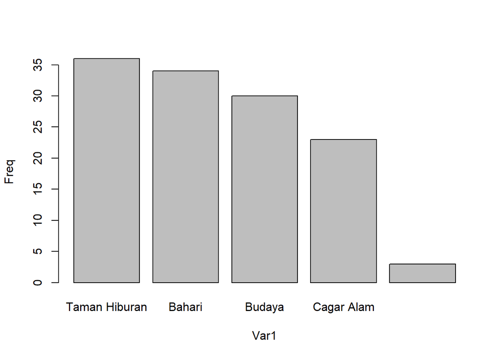

```r
barplot(Freq~Var1, number_category)
```

“Taman Hiburan” Category have most destination place.

## 4.3 Average Price by Category

```r
aggregate(x=Price~Category,data = place_yogya, FUN = mean)
```

| Category | Price |
| --- | --- |
| Bahari | 7470.588 |
| Budaya | 33083.333 |
| Cagar Alam | 31934.783 |
| Pusat Perbelanjaan | 0.000 |
| Taman Hiburan | 13069.444 |

“Budaya” Category has the highest average price.

### 4.3.1 5 Highest Charges Place

```r
place_price <- aggregate(x=Price~Place_Name,data = place_yogya, FUN = max)
place_price[order(place_price$Price,decreasing = T),][0:5,]
```

|  | Place_Name | Price |
| --- | --- | --- |
| 34 | Goa Jomblang | 500000 |
| 11 | Bukit Panguk Kediwung | 250000 |
| 47 | Kampung Wisata Dipowinatan | 220000 |
| 44 | Jogja Bay Pirates Adventure Waterpark | 150000 |
| 66 | Museum Ullen Sentalu | 100000 |

“Goa Jomblang” has highest price place.

### 4.3.2 5 Lowest Charges Place

```r
place_price_charge <- place_price[place_price$Price!=0,]
place_price_charge[order(place_price_charge$Price,decreasing = F),][0:5,]
```

|  | Place_Name | Price |
| --- | --- | --- |
| 10 | Bukit Lintang Sewu | 2000 |
| 37 | Green Village Gedangsari | 2000 |
| 108 | Seribu Batu Songgo Langit | 2000 |
| 42 | Hutan Pinus Asri | 2500 |
| 46 | Jurang Tembelan Kanigoro | 2500 |

### 4.3.3 Free Charge by Place

```r
place_yogya[place_yogya$Price==0,2]
```

```
#>  [1] Situs Warungboto                   Nol Kilometer Jl.Malioboro
#>  [3] Desa Wisata Sungai Code Jogja Kota Alun Alun Selatan Yogyakarta
#>  [5] Kampung Wisata Kadipaten           Taman Budaya Yogyakarta
#>  [7] Kampung Wisata Sosro Menduran      Tugu Pal Putih Jogja
#>  [9] Candi Donotirto                    Kawasan Malioboro
#> [11] Embung Tambakboyo                  Gedung Agung Yogyakarta
#> [13] Kampung Wisata Rejowinangun        Kauman Pakualaman Yogyakarta
#> [15] Alun-alun Utara Keraton Yogyakarta Gumuk Pasir Parangkusumo
#> [17] Kawasan Wisata Sosrowijayan        Bendung Lepen
#> [19] Ledok Sambi                        Bentara Budaya Yogyakarta (BBY)
#> [21] Desa Wisata Kelor                  Pasar Kebon Empring Bintaran
#> [23] Geoforest Watu Payung Turunan      Pasar Beringharjo
#> [25] Desa Wisata Pulesari
#> 126 Levels: Air Terjun Kedung Pedut ... Wisata Kraton Jogja
```

There are 25 free charge places

### 4.3.4 Free Charge by Category

```r
as.data.frame(table(place_yogya[place_yogya$Price==0,4]))
```

| Var1 | Freq |
| --- | --- |
| Bahari | 0 |
| Budaya | 9 |
| Cagar Alam | 2 |
| Pusat Perbelanjaan | 3 |
| Taman Hiburan | 11 |

Taman Hiburan is most free charge Place

## 4.4 Top 5 Visitors Origin

```r
as.data.frame(sort(table(place_yogya_merge$Location),decreasing = T)[1:5])
```

| Var1 | Freq |
| --- | --- |
| Bekasi, Jawa Barat | 374 |
| Semarang, Jawa Tengah | 214 |
| Yogyakarta, DIY | 189 |
| Lampung, Sumatera Selatan | 176 |
| Bogor, Jawa Barat | 162 |

# 5 Conclusion and Travelling Reccomendation

Yogyakarta have many travelling destination, from free of charges and charges. Yogyakarta have 25 free charge travelling destination. So, if you want to travelling around yogyakarta with low budget, you can consider to visit those 25 places. But in Yogyakarta, also there are charges place with low charge, start from IDR 2.000,00 and the highest charges place IDR 500.000,00. If budget not in your concern, you can choose your destination from most rated and highest rating place in Yogyakarta. Happy Holiday!!!